# Clarifying distance measures

Wilson

July 10, 2016

A friend once said:

> It’s always better to give than to receive.

## Methods for measuring distances

1. Euclidean distance:
   $$d_{euc(x,y)}=\sum_{i=1}^n (x_i−y_i)^2$$
2. Manhattan distance:
   $$d_{man(x,y)}=\sum_{i=1}^n |(x_i−y_i)|$$

in 1) and 2), x and y are two vectors of length n

Correlation-based distance is defined **by subtracting the correlation coefficient from 1**. Different types of correlation methods can be used such as:

1. Pearson correlation distance:
   $$d_{cor(x,y)}=1− \frac {\sum_{i=1}^n (x_i−\bar{x})(y_i−\bar{y})} {\sum_{i=1}^n (x_i−\bar{x})^2 * \sum_{i=1}^n (y_i−\bar{y})^2}$$

```
Pearson correlation measures the degree of a linear relationship between two profiles.
```

2. Eisen cosine correlation distance (Eisen et al., 1998):
   $$d_{eisen(x,y)}=1−\frac{∣\sum_{i=1}^n x_iy_i∣} {\sum_{i=1}^n x^2_i \sum_{i=1}^n y^2_i}$$

```
It’s a special case of Pearson’s correlation with x¯ and y¯ both replaced by zero
```

3. Spearman correlation distance:
   $$d_{spear(x,y)}=1−\frac{\sum_{i=1}^n (x_i'−\bar{x}')(y_i'−\bar{y}')} {\sum_{i=1}^n (x_i'−\bar{x}')^2 \sum_{i=1}^n (y_i'−\bar{y}')^2}$$

where: $x_i'=rank(x_i)$ and $y_i'=rank(y_i).$

```
Spearman correlation method computes the correlation between the rank of x and the rank of y variables.
```

4. Kendall correlation distance:

Kendall correlation method measures the *correspondence* between **the ranking** of x and y variables. The total number of possible pairings of x with y observations is n(n−1)/2, where n is the size of x and y. Begin by ordering the pairs by the x values. If x and y are correlated, then they would have the same relative rank orders. Now, for each yi, count the number of $y_j>y_i$ (concordant pairs (c)) and the number of $y_j<y_i$ (discordant pairs (d)).

$$d_{kend(x,y)}=\frac{1−n_c−n_d} {\frac{1}{2}n(n−1)}$$

Where,

- $n_c$: total number of concordant pairs
- $n_d$: total number of discordant pairs
- $n$: size of x and y

## Distances and scaling

The goal is to make the variables comparable and they will have equal importance in the clustering algorithm. This is particularly recommended when variables are measured in different scales (e.g: kilograms, kilometers, centimeters, …); otherwise, the dissimilarity measures obtained will be severely affected.

Generally variables are scaled to have standard deviation one and mean zero.

$$\frac{{x_i}−center(x)} {scale(x)}$$

The R base `scale()` function can be used to standardize the data. It takes a numeric matrix as an input and performs the scaling on the columns.

## Example

```r
# Load the dataset
data(USArrests)

# Subset of the data
set.seed(123)
ss <- sample(1:50, 10) # Take 10 random rows
df <- USArrests[ss, ] # Subset the 10 rows

# Remove any missing value (i.e, NA values for not available)
# That might be present in the data
df <- na.omit(df)
head(df, n = 6)
```

```
##              Murder Assault UrbanPop Rape
## Iowa            2.2      56       57 11.3
## Rhode Island    3.4     174       87  8.3
## Maryland       11.3     300       67 27.8
## Tennessee      13.2     188       59 26.9
## Utah            3.2     120       80 22.9
## Arizona         8.1     294       80 31.0
```

```r
# Descriptive statistics
desc_stats <- data.frame(
  Min = apply(USArrests, 2, min), # minimum
  Med = apply(USArrests, 2, median), # median
  Mean = apply(USArrests, 2, mean), # mean
  SD = apply(USArrests, 2, sd), # Standard deviation
  Max = apply(USArrests, 2, max) # Maximum
  )
desc_stats <- round(desc_stats, 1)
head(desc_stats)
```

```
##           Min   Med  Mean   SD   Max
## Murder    0.8   7.2   7.8  4.4  17.4
## Assault  45.0 159.0 170.8 83.3 337.0
## UrbanPop 32.0  66.0  65.5 14.5  91.0
## Rape      7.3  20.1  21.2  9.4  46.0
```

```r
# standardization
df.scaled <- scale(df)
head(round(df.scaled, 2))
```

```
##              Murder Assault UrbanPop  Rape
## Iowa          -0.95   -1.21    -0.62 -0.83
## Rhode Island  -0.72    0.06     1.58 -1.18
## Maryland       0.82    1.42     0.12  1.08
## Tennessee      1.19    0.21    -0.47  0.98
## Utah          -0.75   -0.52     1.07  0.51
## Arizona        0.20    1.35     1.07  1.45
```

## R functions for computing distances

There are many functions to compute pairwise distances in R:

- The standard `dist()` function [in `stats` package]
- The function `daisy()` [in `cluster` package]

```
dist(x, method = c("euclidean"", "manhattan"")
```

Correlation based distance measures:

The function cor() compute pairwise correlation coefficients between the columns of the data. In our case columns are variables. We want to compute correlation coefficients between observations. So, the data must be first transposed using the function t() in order to have observations in the columns of the data:

```r
# Compute correlation matrix
res.cor <- cor(t(df.scaled),  method = "pearson")
# Compute distance matrix
dist.cor <- as.dist(1 - res.cor)

round(as.matrix(dist.cor)[1:6, 1:6], 1)
```

```
##              Iowa Rhode Island Maryland Tennessee Utah Arizona
## Iowa          0.0          0.6      1.9       1.3  0.2     1.0
## Rhode Island  0.6          0.0      1.7       1.9  0.5     0.9
## Maryland      1.9          1.7      0.0       0.5  1.7     0.7
## Tennessee     1.3          1.9      0.5       0.0  1.6     1.4
## Utah          0.2          0.5      1.7       1.6  0.0     0.5
## Arizona       1.0          0.9      0.7       1.4  0.5     0.0
```

```
daisy(x, metric = c("euclidean", "manhattan", "gower"), stand = FALSE)
```

```r
library(cluster)
# Load data
data(flower)
head(flower)
```

```
##   V1 V2 V3 V4 V5 V6  V7 V8
## 1  0  1  1  4  3 15  25 15
## 2  1  0  0  2  1  3 150 50
## 3  0  1  0  3  3  1 150 50
## 4  0  0  1  4  2 16 125 50
## 5  0  1  0  5  2  2  20 15
## 6  0  1  0  4  3 12  50 40
```

```r
# Distance matrix
dd <- as.matrix(daisy(flower))
head(round(dd[, 1:6], 2))
```

```
##      1    2    3    4    5    6
## 1 0.00 0.89 0.53 0.35 0.41 0.23
## 2 0.89 0.00 0.51 0.55 0.62 0.66
## 3 0.53 0.51 0.00 0.57 0.37 0.30
## 4 0.35 0.55 0.57 0.00 0.64 0.42
## 5 0.41 0.62 0.37 0.64 0.00 0.34
## 6 0.23 0.66 0.30 0.42 0.34 0.00
```

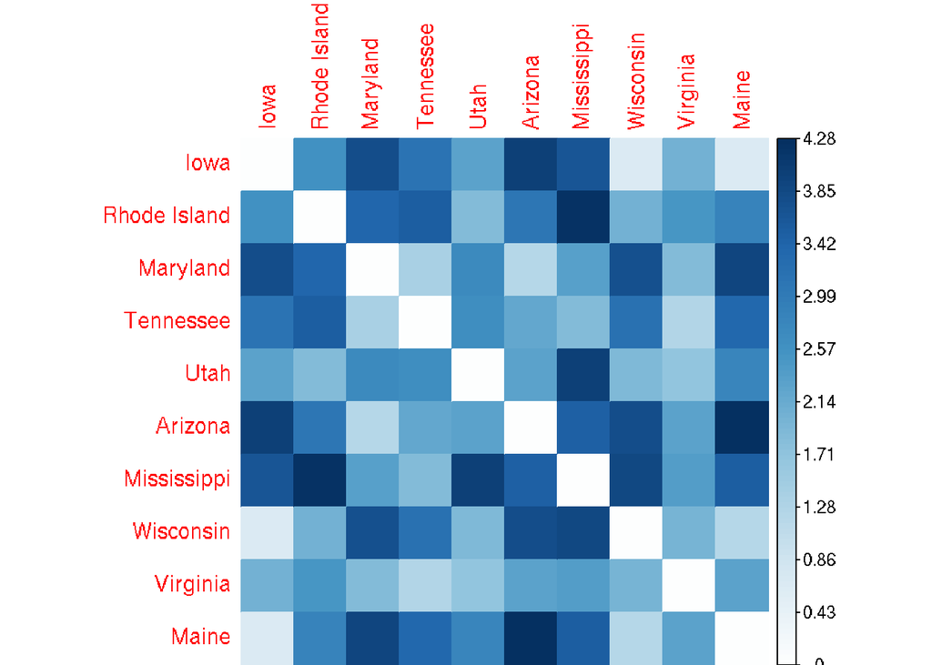

```r
# install.packages("corrplot")
dist.eucl <- dist(df.scaled, method = "euclidean")
library("corrplot")
# Euclidean distance
corrplot(as.matrix(dist.eucl), is.corr = FALSE, method = "color")
```

## info

If you want learn more (example), please refer to the [original post](http://www.sthda.com/english/wiki/clarifying-distance-measures-unsupervised-machine-learning)